# L4P2: Testes de hipótese e p-valores

Import dos dados

```r
sat_gpa = read_csv(here::here("data/sat-gpa.csv"), col_types = "iidd") %>%
  rename("Math" = math_SAT, "Verb" = verb_SAT, "Comp" = comp_GPA, "Geral" = univ_GPA)
glimpse(sat_gpa)
```

```
## Rows: 105
## Columns: 4
## $ Math  <int> 643, 558, 583, 685, 592, 562, 573, 559, 552, 617, 684, 568, 604,…
## $ Verb  <int> 589, 512, 503, 602, 538, 486, 548, 536, 583, 591, 649, 592, 582,…
## $ Comp  <dbl> 3.76, 2.87, 2.54, 3.83, 3.29, 2.64, 2.86, 2.03, 2.81, 3.41, 3.61…
## $ Geral <dbl> 3.52, 2.91, 2.40, 3.47, 3.47, 2.37, 2.40, 2.24, 3.02, 3.32, 3.59…
```

```r
smiles = read_csv(here::here("data/leniency.csv"), col_types = "cdc")
glimpse(smiles)
```

```
## Rows: 136
## Columns: 3
## $ smile      <chr> "false smile", "false smile", "false smile", "false smile",…
## $ leniency   <dbl> 2.5, 5.5, 6.5, 3.5, 3.0, 3.5, 6.0, 5.0, 4.0, 4.5, 5.0, 5.5,…
## $ with_smile <chr> "yes", "yes", "yes", "yes", "yes", "yes", "yes", "yes", "ye…
```

Calculo dos interválos de confiança

```r
theta_math <- function(d, i) {
    r = d %>%
        slice(i) %>%
        summarise(r = cor(Math, Comp, method = "pearson")) %>%
        pull(r)
    r
}
ci_math = boot(data = sat_gpa,
           statistic = theta_math,
           R = 2000) %>%
    tidy(conf.level = .95,
         conf.method = "bca",
         conf.int = TRUE)
theta_verb <- function(d, i) {
    r = d %>%
        slice(i) %>%
        summarise(r = cor(Verb, Comp, method = "pearson")) %>%
        pull(r)
    r
}
ci_verb = boot(data = sat_gpa,
           statistic = theta_verb,
           R = 2000) %>%
    tidy(conf.level = .95,
         conf.method = "bca",
         conf.int = TRUE)
cis_sta = bind_rows(.id='name', "Verb" = ci_verb, "Math" = ci_math)
```

```r
theta <- function(d, i) {
    agrupado = d %>%
        slice(i) %>%
        summarise(media = mean(leniency)) %>%
        pull(media)
    agrupado
}
theta_false <- function(d, i) {
    agrupado = d %>%
        slice(i) %>%
        group_by(smile) %>%
        summarise(media = mean(leniency))
    b = agrupado %>% filter(smile == "no smile (control)") %>% pull(media)
    l = agrupado %>% filter(smile == "false smile") %>% pull(media)
    l - b
}
theta_felt <- function(d, i) {
    agrupado = d %>%
        slice(i) %>%
        group_by(smile) %>%
        summarise(media = mean(leniency))
    b = agrupado %>% filter(smile == "no smile (control)") %>% pull(media)
    l = agrupado %>% filter(smile == "felt smile") %>% pull(media)
    l - b
}
theta_miserable <- function(d, i) {
    agrupado = d %>%
        slice(i) %>%
        group_by(smile) %>%
        summarise(media = mean(leniency))
    b = agrupado %>% filter(smile == "no smile (control)") %>% pull(media)
    l = agrupado %>% filter(smile == "miserable smile") %>% pull(media)
    l - b
}

ci_baseline = boot(data = filter(smiles, smile == "no smile (control)"),
           statistic = theta,
           R = 2000) %>%
    tidy(conf.level = .95,
         conf.method = "bca",
         conf.int = TRUE)

ci_false = boot(data = filter(smiles, smile == "false smile"),
           statistic = theta,
           R = 2000) %>%
    tidy(conf.level = .95,
         conf.method = "bca",
         conf.int = TRUE)

ci_felt = boot(data = filter(smiles, smile == "felt smile"),
           statistic = theta,
           R = 2000) %>%
    tidy(conf.level = .95,
         conf.method = "bca",
         conf.int = TRUE)

ci_miserable = boot(data = filter(smiles, smile == "miserable smile"),
           statistic = theta,
           R = 2000) %>%
    tidy(conf.level = .95,
         conf.method = "bca",
         conf.int = TRUE)
cis_means = bind_rows(.id='name', "No Smile" = ci_baseline, "False Smile" = ci_false, "Felt Smile" = ci_felt, "Miserable Smile" = ci_miserable)

ci_base_false = boot(data = smiles,
           statistic = theta_false,
           R = 2000) %>%
    tidy(conf.level = .95,
         conf.method = "bca",
         conf.int = TRUE)

ci_base_felt = boot(data = smiles,
           statistic = theta_felt,
           R = 2000) %>%
    tidy(conf.level = .95,
         conf.method = "bca",
         conf.int = TRUE)

ci_base_miserable = boot(data = smiles,
           statistic = theta_miserable,
           R = 2000) %>%
    tidy(conf.level = .95,
         conf.method = "bca",
         conf.int = TRUE)

cis_smiles_comp = bind_rows(.id='name', "False Smile" = ci_base_false, "Felt Smile" = ci_base_felt, "Miserable Smile" = ci_base_miserable)
```

# Relação SAT e GPA

Os dados se tratam de uma pesquisa com alunos que se formaram em Computação em uma universidade americana. Foram coletados dados da prova SAT e do desempenho deles no curso de Computação (GPA). [1]

## Os dados

Como podemos ver no histograma abaixo (Figura 1), temos que a distribuição de SAT para Matemática é assimétrica com cauda à direita, mais concentrado por volta de 550, enquanto para Expressão Verbal é uma distribuição simétrica, com centro em aproximadamente 600.

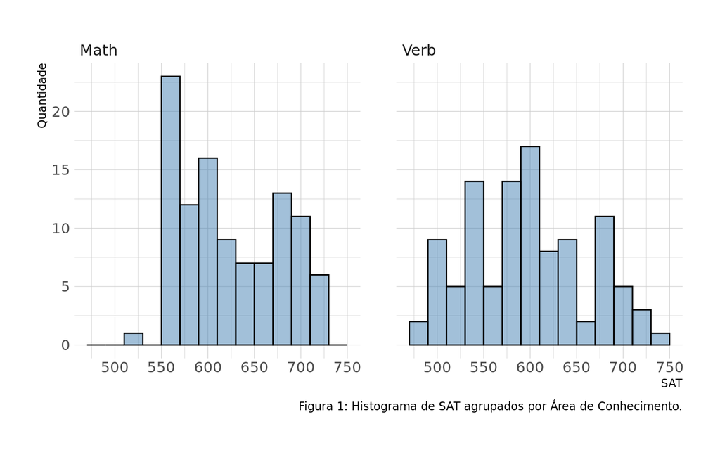

```r
sat_gpa %>%
  pivot_longer(c(Math, Verb), values_to = "SAT") %>%
  ggplot(aes(x=SAT )) +
    geom_histogram(fill = "steelblue", binwidth = 20, color = "black", alpha = .5) +
    ylab("Quantidade") +
    xlab("SAT") +
    facet_wrap(~name) +
    theme(plot.title=element_text(hjust=0.5), text=element_text(size=12)) +
    labs(caption = "Figura 1: Histograma de SAT agrupados por Área de Conhecimento.")
```

```r
ggsave("figure1.png", width = 8, height = 5, dpi=600)
```

Para os dados de GPA, o histograma (Figura 2) mostra uma distribuição assimétrica com cauda à esquerda, tanto para Computação como em Geral, se concentrando por volta de 3.3.

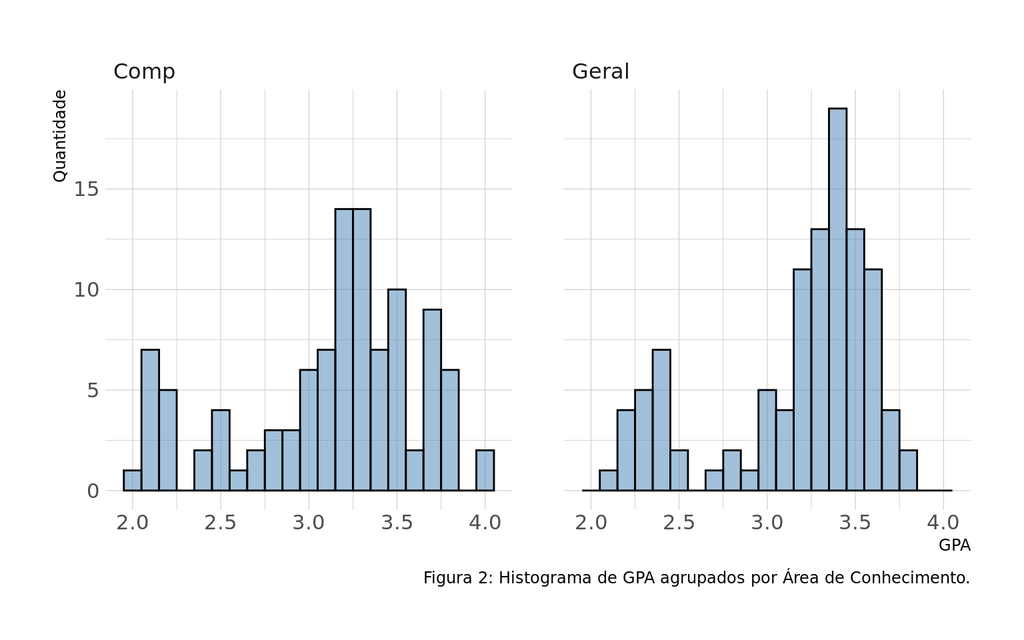

```r
sat_gpa %>%
  pivot_longer(c(Comp, Geral), values_to = "GPA") %>%
  ggplot(aes(x=GPA )) +
    geom_histogram(fill = "steelblue", binwidth = .1, color = "black", alpha = .5) +
    ylab("Quantidade") +
    xlab("GPA") +
    facet_wrap(~name) +
    theme(plot.title=element_text(hjust=0.5), text=element_text(size=12)) +
    labs(caption = "Figura 2: Histograma de GPA agrupados por Área de Conhecimento.")
```

```r
ggsave("figure2.png", width = 8, height = 5, dpi=600)
```

## Correlação

Podemos visualizar na distribuição SAT x GPA (Figura 3), que ambas têm uma correlação positiva entre si. Para Matemática calculamos um r = 0.69 e em Expressão Verbal r = 0.64. Podemos notar uma diferença desprezível nas duas áreas. Em azul temos a reta calculada pela regressão linear dos dados.

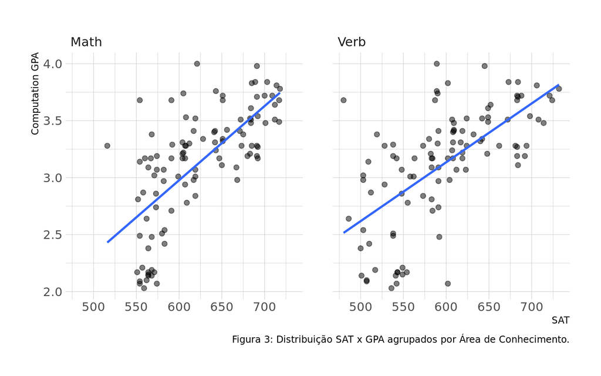

```r
sat_gpa %>%
  pivot_longer(c(Math, Verb), values_to = "SAT") %>%
  ggplot(aes(x=SAT, y=Comp )) +
    geom_point(alpha=.5, size=2)+
    ylab("Computation GPA") +
    facet_wrap(~name) +
    geom_smooth(method = "lm", se = FALSE)+
    theme(plot.title=element_text(hjust=0.5), text=element_text(size=12)) +
    labs(caption = "Figura 3: Distribuição SAT x GPA agrupados por Área de Conhecimento.")
```

```r
ggsave("figure3.png", width = 8, height = 5, dpi=600)
```

Calculando o intervalo de confiança de 95% do coeficiente de Pearson, **notamos que temos uma correlação forte entre matemática e computação [0.58, 0.77] (p = 5.3e-16), enquanto que em Expressão verbal é plausível que seja ou uma relação média, ou forte [0.50, 0.73] (p = 2.3e-13).** Podemos melhor visualizar os intervalos na figura 4.

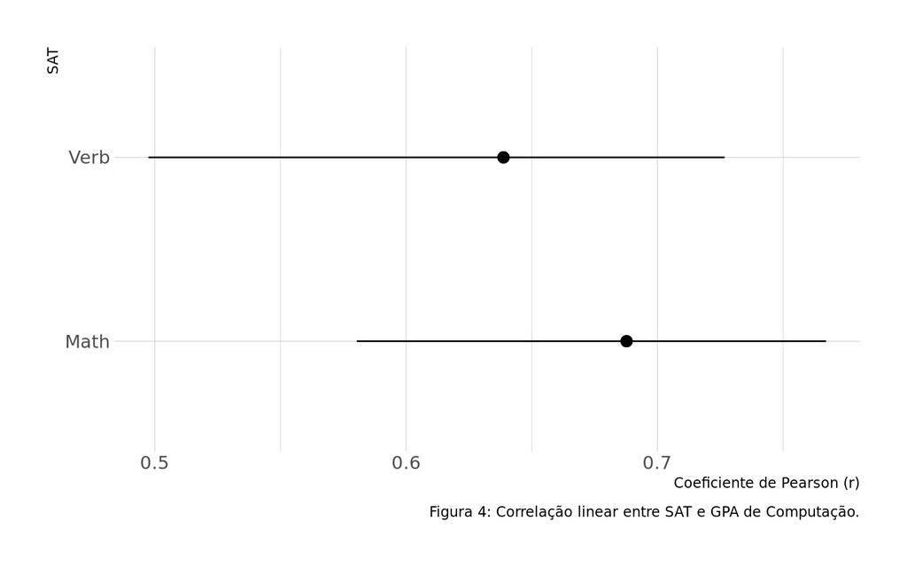

```r
cis_sta %>%
    ggplot(aes(y=name, x=statistic, xmin=conf.low, xmax=conf.high)) +
    geom_linerange() +
    geom_point(size=3) +
    xlab("Coeficiente de Pearson (r)") +
    ylab("SAT") +
    theme(plot.title=element_text(hjust=0.5), text=element_text(size=12)) +
    geom_point(size=3) +
    labs(caption = "Figura 4: Correlação linear entre SAT e GPA de Computação.")
```

```r
ggsave("figure4.png", width=8, height = 5, dpi=600)
```

## Teste de Hipótese

```r
cor.test(sat_gpa$Math, sat_gpa$Comp) %>%
  tidy()
```

```
## # A tibble: 1 x 8
##   estimate statistic  p.value parameter conf.low conf.high method    alternative
##      <dbl>     <dbl>    <dbl>     <int>    <dbl>     <dbl> <chr>     <chr>
## 1    0.688      9.61 5.34e-16       103    0.571     0.777 Pearson'… two.sided
```

```r
cor.test(sat_gpa$Verb, sat_gpa$Comp) %>%
  tidy()
```

```
## # A tibble: 1 x 8
##   estimate statistic  p.value parameter conf.low conf.high method    alternative
##      <dbl>     <dbl>    <dbl>     <int>    <dbl>     <dbl> <chr>     <chr>
## 1    0.639      8.43 2.28e-13       103    0.509     0.740 Pearson'… two.sided
```

# Experimento com Sorrisos

Os dados foram coletados com questionários a fim de estudar o impacto do sorriso no julgamento de culpa das pessoas. O dado de leniência varia de 0 a 9, quanto mais próximo de 9, mas leniente foi o julgamento do entrevistado. [2,3]

## Os Dados

Vemos que em sua maioria, as distribuições são assimétricas com cauda à direita (Figura 5).

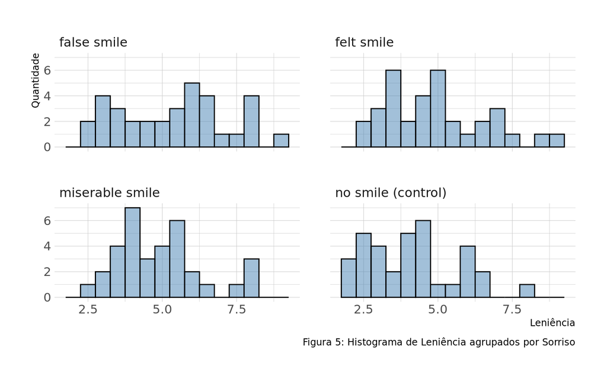

```r
smiles %>%
  ggplot(aes(x=leniency )) +
    geom_histogram(fill = "steelblue", binwidth = .5, color = "black", alpha = .5) +
    ylab("Quantidade") +
    xlab("Leniência") +
    facet_wrap(~smile) +
    theme(plot.title=element_text(hjust=0.5), text=element_text(size=12)) +
    labs(caption = "Figura 5: Histograma de Leniência agrupados por Sorriso")
```

```r
ggsave("figure5.png", width = 8, height = 5, dpi=600)
```

Na Figura 6, temos as médias de leniência com um intervalo de confiança de 95%. Notamos que o False Smile possui uma média maior de leniência em relação ao baseline. **No geral, uma pessoa sorrindo tem em média mais leniência (p = .003).**

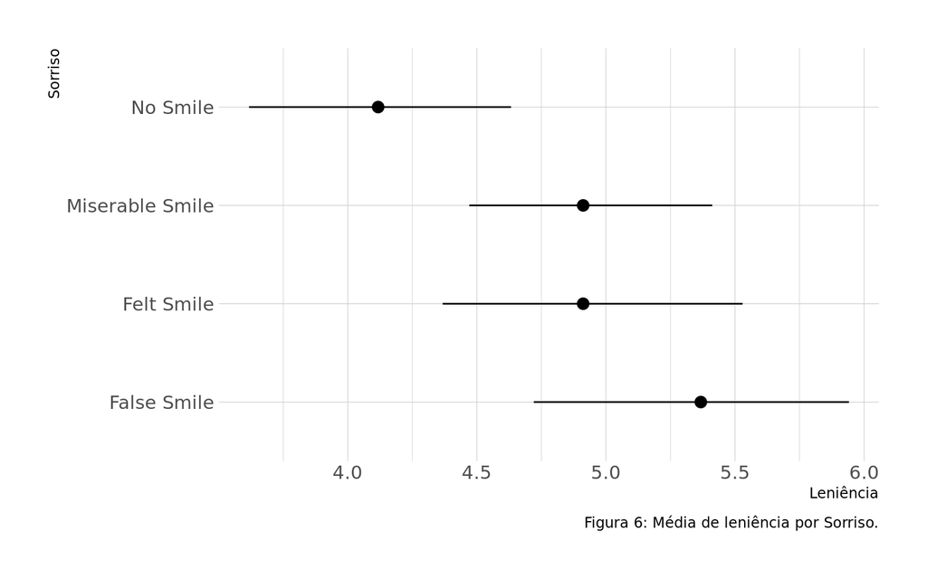

```r
cis_means %>%
    ggplot(aes(y=name, x=statistic, xmin=conf.low, xmax=conf.high)) +
    geom_linerange() +
    geom_point(size=3) +
    xlab("Leniência") +
    ylab("Sorriso") +
    theme(plot.title=element_text(hjust=0.5), text=element_text(size=12)) +
    labs(caption = "Figura 6: Média de leniência por Sorriso.")
```

```r
ggsave("figure6.png", width=8, height = 5, dpi=600)
```

## Comparação com o Baseline

[figure not shown]

```r
cis_smiles_comp %>%
    ggplot(aes(y=name, x=statistic, xmin=conf.low, xmax=conf.high)) +
    geom_linerange() +
    geom_point(size=3) +
    xlab("Coeficiente de Pearson (r)") +
    ylab("SAT") +
    theme(plot.title=element_text(hjust=0.5), text=element_text(size=12)) +
    geom_point(size=3) +
    labs(caption = "Figura 7: Diferença entre as médias em relação ao Baseline.")
```

```r
ggsave("figure7.png", width=8, height = 5, dpi=600)
```

## Teste de Hipótese

```r
t.test(smiles %>% filter(with_smile == "yes") %>% pull(leniency),
       smiles %>% filter(with_smile == "no") %>% pull(leniency))%>%
  tidy()
```

```
## # A tibble: 1 x 10
##   estimate estimate1 estimate2 statistic p.value parameter conf.low conf.high
##      <dbl>     <dbl>     <dbl>     <dbl>   <dbl>     <dbl>    <dbl>     <dbl>
## 1    0.946      5.06      4.12      3.07 0.00322      61.1    0.329      1.56
## # … with 2 more variables: method <chr>, alternative <chr>
```

```r
t.test(smiles %>% filter(smile == "felt smile") %>% pull(leniency),
       smiles %>% filter(smile == "no smile (control)") %>% pull(leniency))%>%
  tidy()
```

```
## # A tibble: 1 x 10
##   estimate estimate1 estimate2 statistic p.value parameter conf.low conf.high
##      <dbl>     <dbl>     <dbl>     <dbl>   <dbl>     <dbl>    <dbl>     <dbl>
## 1    0.794      4.91      4.12      2.04  0.0452      65.4   0.0174      1.57
## # … with 2 more variables: method <chr>, alternative <chr>
```

```r
t.test(smiles %>% filter(smile == "false smile") %>% pull(leniency),
       smiles %>% filter(smile == "no smile (control)") %>% pull(leniency))%>%
  tidy()
```

```
## # A tibble: 1 x 10
##   estimate estimate1 estimate2 statistic p.value parameter conf.low conf.high
##      <dbl>     <dbl>     <dbl>     <dbl>   <dbl>     <dbl>    <dbl>     <dbl>
## 1     1.25      5.37      4.12      3.06 0.00319      63.9    0.435      2.06
## # … with 2 more variables: method <chr>, alternative <chr>
```

```r
t.test(smiles %>% filter(smile == "miserable smile") %>% pull(leniency),
       smiles %>% filter(smile == "no smile (control)") %>% pull(leniency))%>%
  tidy()
```

```
## # A tibble: 1 x 10
##   estimate estimate1 estimate2 statistic p.value parameter conf.low conf.high
##      <dbl>     <dbl>     <dbl>     <dbl>   <dbl>     <dbl>    <dbl>     <dbl>
## 1    0.794      4.91      4.12      2.20  0.0314      65.9   0.0732      1.52
## # … with 2 more variables: method <chr>, alternative <chr>
```

# Referências

1 - https://github.com/cienciadedados-ufcg/estudo-ics-utils/blob/main/data/sat-gpa.csv 2 - LaFrance, M., & Hecht, M. A. (1995) Why smiles generate leniency. Personality and Social Psychology Bulletin, 21, 207-214. 3 - https://github.com/cienciadedados-ufcg/estudo-ics-utils/blob/main/data/leniency.csv